# Movies_project

cduan34

7/1/2018

# Data

In this project, we will explore a dataset that contains information about movies, including ratings, budget, gross revenue and other attributes. It was prepared by Dr. Guy Lebanon, and here is his description of the dataset:

> The file [`movies_merged`](https://s3.amazonaws.com/content.udacity-data.com/courses/gt-cs6242/project/movies_merged) contains a dataframe with the same name that has 40K rows and 39 columns. Each row represents a movie title and each column represents a descriptor such as `Title`, `Actors`, and `Budget`. I collected the data by querying IMDb’s API (see [www.omdbapi.com](http://www.omdbapi.com/)) and joining it with a separate dataset of movie budgets and gross earnings (unknown to you). The join key was the movie title. This data is available for personal use, but IMDb’s terms of service do not allow it to be used for commercial purposes or for creating a competing repository.

# Objective

The goal is to investigate the relationship between the movie descriptors and the box office success of movies, as represented by the variable `Gross`. This task is extremely important as it can help a studio decide which titles to fund for production, how much to bid on produced movies, when to release a title, how much to invest in marketing and PR, etc. This information is most useful before a title is released, but it is still very valuable after the movie is already released to the public (for example it can affect additional marketing spend or how much a studio should negotiate with on-demand streaming companies for “second window” streaming rights).

# Setup

## Load data

Make sure you’ve downloaded the [`movies_merged`](https://s3.amazonaws.com/content.udacity-data.com/courses/gt-cs6242/project/movies_merged) file and it is in the current working directory. Now load it into memory:

```r
load('movies_merged')
cat("Dataset has", dim(movies_merged)[1], "rows and",
    dim(movies_merged)[2], "columns", end="\n", file="")
```

```
## Dataset has 40789 rows and 39 columns
```

This creates an object of the same name (`movies_merged`). For convenience, you can copy it to `df` and start using it:

```r
df = movies_merged
cat("Column names:", end="\n", file="")
```

```
## Column names:
```

```r
colnames(df)
```

```
##  [1] "Title"             "Year"              "Rated"
##  [4] "Released"          "Runtime"           "Genre"
##  [7] "Director"          "Writer"            "Actors"
## [10] "Plot"              "Language"          "Country"
## [13] "Awards"            "Poster"            "Metascore"
## [16] "imdbRating"        "imdbVotes"         "imdbID"
## [19] "Type"              "tomatoMeter"       "tomatoImage"
## [22] "tomatoRating"      "tomatoReviews"     "tomatoFresh"
## [25] "tomatoRotten"      "tomatoConsensus"   "tomatoUserMeter"
## [28] "tomatoUserRating"  "tomatoUserReviews" "tomatoURL"
## [31] "DVD"               "BoxOffice"         "Production"
## [34] "Website"           "Response"          "Budget"
## [37] "Domestic_Gross"    "Gross"             "Date"
```

## Load R packages

Load any R packages that we will need to use

```r
library(ggplot2)
library(GGally)
# install.packages("ggpubr")
# install.packages("tm")
# install.packages("magrittr")
# install.packages("NLP")
library(ggpubr)
library(tm)
library(reshape2)
```

# Tasks

## 1. Remove non-movie rows

The variable `Type` captures whether the row is a movie, a TV series, or a game. Remove all rows from `df` that do not correspond to movies.

```r
# Remove all rows from df that do not correspond to movies
df2 <- df[df$Type == "movie",]
dim(df2)
```

```
## [1] 40000    39
```

## 2. Process `Runtime` column

The variable `Runtime` represents the length of the title as a string. Write R code to convert it to a numeric value (in minutes) and replace `df$Runtime` with the new numeric column.

```r
# Replace df$Runtime with a numeric column containing the runtime in minutes
df2$Runtime = sapply(df2$Runtime, function(x)
  ifelse(x == "N/A", NA, as.numeric(unlist(strsplit(x, " "))[[1]])))
```

Now investigate the distribution of `Runtime` values and how it changes over years (variable `Year`, which you can bucket into decades) and in relation to the budget (variable `Budget`).

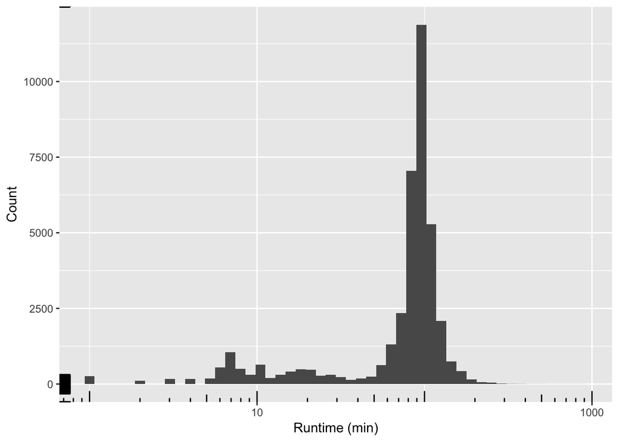

```r
# Investigate the distribution of Runtime values and how it varies by Year and Budget

# Distribution of runtime
ggplot(data = df2, aes(x=Runtime)) +
  geom_histogram(bins = 50, na.rm = TRUE)  +
  scale_x_log10() +
  labs(x = "Runtime (min)") +
  annotation_logticks() +
  labs(y = "Count")
```

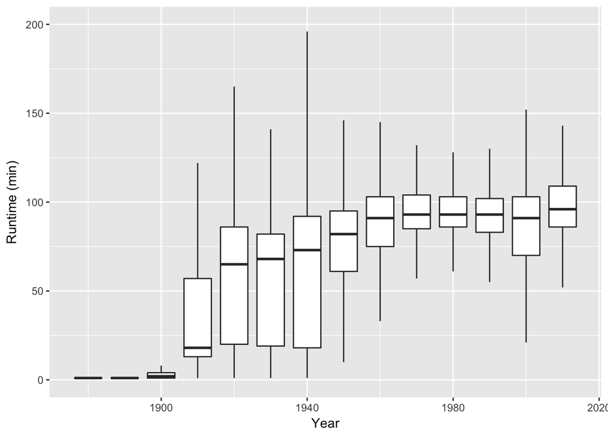

```r
# Runtime vs. Year
# bucket Year into Decades
df2$YearInDecades = df2$Year - df2$Year %% 10
ggplot(data = df2, aes(x=YearInDecades, y = Runtime, group=YearInDecades)) +
  geom_boxplot(na.rm = TRUE, outlier.shape=NA) +
  labs(x = "Year", y = "Runtime (min)") +
  coord_cartesian(ylim=c(0, 200))
```

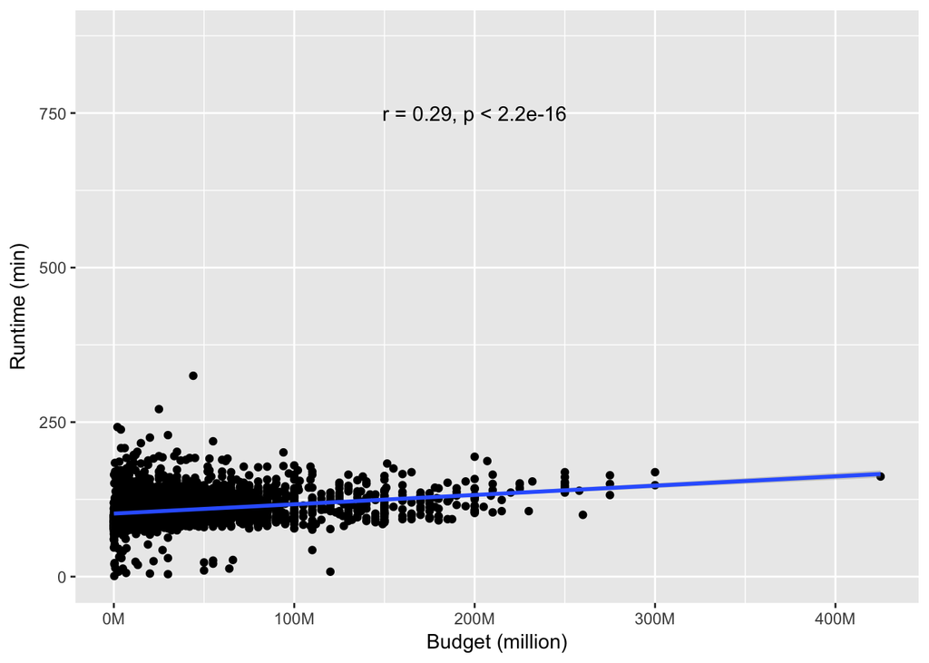

```r
# Runtime vs. Budget
ggplot(data = df2, aes(x=Budget, y = Runtime)) +
  geom_point(na.rm = TRUE) + geom_smooth(method=lm, na.rm = TRUE) +
  stat_cor(method = "pearson", label.x = 200000000,
           label.y = 750, na.rm = TRUE) + # Need the ggpubr library
  labs(x = "Budget (million)", y = "Runtime (min)") +
  scale_x_continuous(breaks=seq(0, 450000000, 100000000),
                     labels = function(x){paste0(x/1000000, 'M')})
```

**Analysis**: 1) Overall, the distribution of majority of movie runtime appoximate a normal distribution centered at ~100 mins. However, there is a substantial negative tail of movies with much shorter runtime. 2) Regarding the relationship between runtime and year, the boxplot shows that the runtime increases in the begining (roughly from 1880 to 1950), and plateaus starting from the 1960s with median runtime around 100 mins. Also, there are large variance (IQR) in movie runtime from 1910 - 1940, after that, the movie runtimes tend to be really close to be around 90-100 mins. 3) Regarding the relationship between runtime and budget, the scatter plot demonstrates a weak positive correllation between runtime and budget.